# A&E Attendances

PLR

2024-04-22

## 1. Load required data

We start by loading required A&E Attendances Type I, Type II and Type III data from NHS England website. Link to the data:. Downloaded file “Monthly A&E Time Series March 2024 (XLS,403K)”https://www.england.nhs.uk/statistics/wp-content/uploads/sites/2/2024/04/Monthly-AE-Time-Series-March-2024.xls

And this time for this Markdown report we have processed first using Targets. The first Target object we have created in this pipeline is called `clean_ATT_data` after cleansing and importing the original .xsl file we had in our imput folder.

Use **echo=TRUE** to display both the *code* and *output* of the R code chunk, as in the example below:

```r
# Read csv file
tar_read(clean_ATT_data)
```

```
## # A tibble: 164 × 4
##    date       AE_att_TypeI AE_att_TypeII AE_att_TypeIII
##    <date>            <int>         <int>          <int>
##  1 2010-08-01      1138652         54371         559358
##  2 2010-09-01      1150728         55181         550359
##  3 2010-10-01      1163143         54961         583244
##  4 2010-11-01      1111294         53727         486005
##  5 2010-12-01      1159203         45536         533000
##  6 2011-01-01      1133880         51584         542331
##  7 2011-02-01      1053707         51249         494407
##  8 2011-03-01      1225221         57900         580318
##  9 2011-04-01      1197212         54042         593119
## 10 2011-05-01      1221687         57066         594940
## # ℹ 154 more rows
```

To populate the inline text, we can load this Target object **clean_ATT_data** into our R Environment using `tar_load()` function, `tar_load(clean_ATT_data)`

```r
tar_load(clean_ATT_data)
# Assign data frame from Targets to new object called AE_data
AE_data <- clean_ATT_data
AE_data
```

```
## # A tibble: 164 × 4
##    date       AE_att_TypeI AE_att_TypeII AE_att_TypeIII
##    <date>            <int>         <int>          <int>
##  1 2010-08-01      1138652         54371         559358
##  2 2010-09-01      1150728         55181         550359
##  3 2010-10-01      1163143         54961         583244
##  4 2010-11-01      1111294         53727         486005
##  5 2010-12-01      1159203         45536         533000
##  6 2011-01-01      1133880         51584         542331
##  7 2011-02-01      1053707         51249         494407
##  8 2011-03-01      1225221         57900         580318
##  9 2011-04-01      1197212         54042         593119
## 10 2011-05-01      1221687         57066         594940
## # ℹ 154 more rows
```

Meaning we can start populating any `inline` text from this markdown document directly from the Targets pipeline output. These are the variables from the above Target object, `names(AE_data)`: [1] “date” “AE_att_TypeI” “AE_att_TypeII” “AE_att_TypeIII”

## 2. Reference period

Today’s date is:**22 April**. This report was published on the week starting on **20 April 2024**. It covers A&E Attendances data from **01 August 2010** as first month in the existing input file to **01 March 2024** as the latest available data point.

## 4. Year 2023/24 Type I, TypeII, Type III table details

The table below displays the latest attendances figures by month.

```r
names(AE_data)
```

```
## [1] "date"           "AE_att_TypeI"   "AE_att_TypeII"  "AE_att_TypeIII"
```

```r
AE_data_2013_gt <- AE_data %>% select(Date = date,
                                 TypeI = AE_att_TypeI,
                                 Type2 = AE_att_TypeII,
                                 Type3 = AE_att_TypeIII) %>%
                          filter(Date >= '2023-01-01')
# Build a gt table from the previous AE data
# Formatting numbers with thousands separator, adding title and subtitle
library(gt)
AE_table <-gt(AE_data_2013_gt)

# Att title to table
AE_table_thousands <- AE_table %>%
  tab_header(
    title = md("**A&E Attendances in England. 2023 period**") ,
    subtitle = md("By type(*Type I*,*Type II*,*Type III*)")
  ) %>%
  tab_source_note(
    source_note = "Source: NHE England A&E Attendances and Emergency Admissions data"
  ) %>%
  tab_source_note(
    source_note = md("*England Time Series monthly data*")
  ) %>%
  fmt_number( columns = c(TypeI, Type2, Type3), sep_mark = ",", decimals = 0)

AE_table_thousands
```

By type(*Type I*,*Type II*,*Type III*)

| Date | TypeI | Type2 | Type3 |
| --- | --- | --- | --- |
| 2023-01-01 | 1,243,898 | 42,076 | 682,364 |
| 2023-02-01 | 1,206,386 | 41,717 | 666,176 |
| 2023-03-01 | 1,372,403 | 46,803 | 746,745 |
| 2023-04-01 | 1,271,145 | 42,632 | 716,211 |
| 2023-05-01 | 1,400,815 | 45,826 | 794,708 |
| 2023-06-01 | 1,389,009 | 46,196 | 785,749 |
| 2023-07-01 | 1,379,854 | 45,513 | 769,533 |
| 2023-08-01 | 1,323,647 | 43,923 | 738,580 |
| 2023-09-01 | 1,369,045 | 42,631 | 754,065 |
| 2023-10-01 | 1,413,560 | 44,769 | 761,289 |
| 2023-11-01 | 1,385,701 | 42,365 | 734,056 |
| 2023-12-01 | 1,383,876 | 39,282 | 756,074 |
| 2024-01-01 | 1,397,645 | 42,835 | 784,555 |
| 2024-02-01 | 1,347,297 | 43,868 | 761,196 |
| 2024-03-01 | 1,462,477 | 48,922 | 840,714 |

Source: NHE England A&E Attendances and Emergency Admissions data  
*England Time Series monthly data*

## 5.Area chart displaying Type I, TypeII, Type III Attendances by Type

This final section describe A&E Attendances by type as an area chart, to visualize the contribution of each A&E Attendances type to the overal total number of Attendances

I will mimic the chart displaying different categories by colours displayed in this website: https://epirhandbook.com/en/reports-with-r-markdown.html

```r
# First I need to re-shape this data set from wide to long format
head(AE_data)
```

```
## # A tibble: 6 × 4
##   date       AE_att_TypeI AE_att_TypeII AE_att_TypeIII
##   <date>            <int>         <int>          <int>
## 1 2010-08-01      1138652         54371         559358
## 2 2010-09-01      1150728         55181         550359
## 3 2010-10-01      1163143         54961         583244
## 4 2010-11-01      1111294         53727         486005
## 5 2010-12-01      1159203         45536         533000
## 6 2011-01-01      1133880         51584         542331
```

```r
names(AE_data)
```

```
## [1] "date"           "AE_att_TypeI"   "AE_att_TypeII"  "AE_att_TypeIII"
```

```r
AE_data
```

```
## # A tibble: 164 × 4
##    date       AE_att_TypeI AE_att_TypeII AE_att_TypeIII
##    <date>            <int>         <int>          <int>
##  1 2010-08-01      1138652         54371         559358
##  2 2010-09-01      1150728         55181         550359
##  3 2010-10-01      1163143         54961         583244
##  4 2010-11-01      1111294         53727         486005
##  5 2010-12-01      1159203         45536         533000
##  6 2011-01-01      1133880         51584         542331
##  7 2011-02-01      1053707         51249         494407
##  8 2011-03-01      1225221         57900         580318
##  9 2011-04-01      1197212         54042         593119
## 10 2011-05-01      1221687         57066         594940
## # ℹ 154 more rows
```

```r
#   Pivot longer
# AE_data_long <- AE_data %>%
#                    select(period, type1_att, type2_att, type3_att) %>%
#                    pivot_longer(names_to = "Type",
#                                 cols = 2:ncol(AE_data))
# AE_data_long
```

```r
## [1] "date"           "AE_att_TypeI"   "AE_att_TypeII"  "AE_att_TypeIII"
#   Pivot longer
AE_data_pivot <- AE_data

AE_data_pivot
```

```
## # A tibble: 164 × 4
##    date       AE_att_TypeI AE_att_TypeII AE_att_TypeIII
##    <date>            <int>         <int>          <int>
##  1 2010-08-01      1138652         54371         559358
##  2 2010-09-01      1150728         55181         550359
##  3 2010-10-01      1163143         54961         583244
##  4 2010-11-01      1111294         53727         486005
##  5 2010-12-01      1159203         45536         533000
##  6 2011-01-01      1133880         51584         542331
##  7 2011-02-01      1053707         51249         494407
##  8 2011-03-01      1225221         57900         580318
##  9 2011-04-01      1197212         54042         593119
## 10 2011-05-01      1221687         57066         594940
## # ℹ 154 more rows
```

```r
AE_data_long <- AE_data_pivot %>%
                pivot_longer(names_to = "Type",
                                  cols = 2:ncol(AE_data_pivot))
AE_data_long
```

```
## # A tibble: 492 × 3
##    date       Type             value
##    <date>     <chr>            <int>
##  1 2010-08-01 AE_att_TypeI   1138652
##  2 2010-08-01 AE_att_TypeII    54371
##  3 2010-08-01 AE_att_TypeIII  559358
##  4 2010-09-01 AE_att_TypeI   1150728
##  5 2010-09-01 AE_att_TypeII    55181
##  6 2010-09-01 AE_att_TypeIII  550359
##  7 2010-10-01 AE_att_TypeI   1163143
##  8 2010-10-01 AE_att_TypeII    54961
##  9 2010-10-01 AE_att_TypeIII  583244
## 10 2010-11-01 AE_att_TypeI   1111294
## # ℹ 482 more rows
```

Then we can plot the data by Attendances type.

- How to control the amount of break and minor breaks to display with *date_breaks* and *date_minor_breaks*: https://r-graph-gallery.com/279-plotting-time-series-with-ggplot2.html
- Also this is an example of a Stacked area chart: https://r-graph-gallery.com/136-stacked-area-chart.html

```r
data_area_chart <- AE_data_long %>%
                   select(date,Type,value)
data_area_chart
```

```
## # A tibble: 492 × 3
##    date       Type             value
##    <date>     <chr>            <int>
##  1 2010-08-01 AE_att_TypeI   1138652
##  2 2010-08-01 AE_att_TypeII    54371
##  3 2010-08-01 AE_att_TypeIII  559358
##  4 2010-09-01 AE_att_TypeI   1150728
##  5 2010-09-01 AE_att_TypeII    55181
##  6 2010-09-01 AE_att_TypeIII  550359
##  7 2010-10-01 AE_att_TypeI   1163143
##  8 2010-10-01 AE_att_TypeII    54961
##  9 2010-10-01 AE_att_TypeIII  583244
## 10 2010-11-01 AE_att_TypeI   1111294
## # ℹ 482 more rows
```

## 6.Area chart displaying Type I, TypeII, Type III Attendances by Type

### 6.1 Building plot in Markdown report

This final section describe A&E Attendances by type as an area chart, to visualize the contribution of each A&E Attendances type to the overall total number of Attendances

I will mimic the chart displaying different categories by colours displayed in this website: https://epirhandbook.com/en/reports-with-r-markdown.html

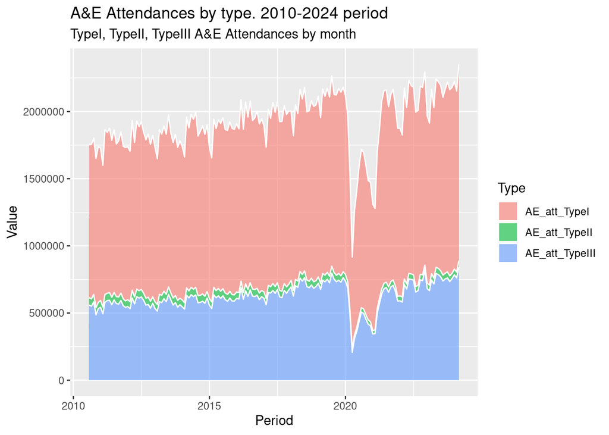

```r
library(viridis)
library(hrbrthemes)

area_chart <- ggplot(data_area_chart, aes(x = date, y = value, fill = Type)) +
      labs(title = "A&E Attendances by type. 2010-2024 period",
         subtitle = "TypeI, TypeII, TypeIII A&E Attendances by month",
         x = "Period", y = "Value" ) +
  geom_area(alpha = 0.6, size = .5, colour = "white")
area_chart
```

### 6.2 Using targets object

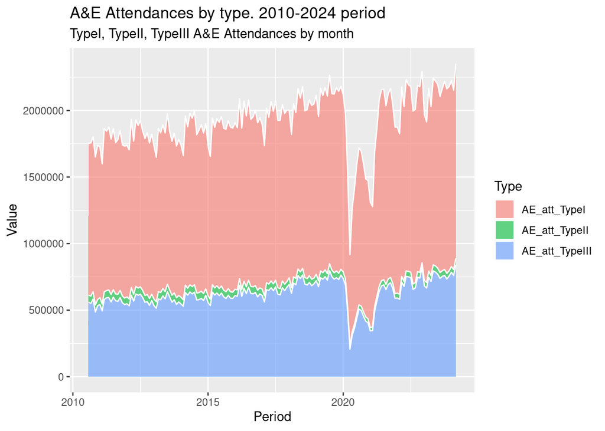

```r
tar_read(area_chart)
```